# R scripts for SEA-AD comparison

Jeremy Miller

December 2022

## Overview

This notebook includes script for generating supplemental figures for the manuscript: “Inter-individual genomic and transcriptomic variation in human cortical cell types” [(bioRxiv link)](https://www.biorxiv.org/content/10.1101/2022.10.07.511366v1.full) that relates to comparison with aged donors with and without Alzheimer’s disease from the Seattle Alzheimer’s Disease Brain Cell Atlas (SEA-AD) at sea-ad.org.

Prior to running this script please perform the following steps:  
1. Run the script called “abundance_variableGenes_randomForest.Rmd”. **To save time reloading the data, we’d suggest running this script in the same R instance without closing R.**  
2. Download the h5ad file that contains all the single nucleus RNA-Seq data from SEA-AD. This is a file called “SEAAD_MTG_RNAseq_final-nuclei.2022-08-18.h5ad” that [can be downloaded here](https://sea-ad-single-cell-profiling.s3.amazonaws.com/index.html#MTG/RNAseq/). This should be saved to a folder called “SEAAD” in your working directory. This is called only to access the metadata.  
3. Download all the individual subclass files from the SEA-AD instance of cellxgene [at this link](https://cellxgene.cziscience.com/collections/1ca90a2d-2943-483d-b678-b809bf464c30). In this script we use the h5ad files rather than the Seurat files because L2/3 IT is too large to save in Seurat format. These files are used for the gene expression data (except L2/3 IT, which is excluded). **Note that the data from these files is an exact match of the data on AWS, but the meta-data is incomplete, and therefore the file from AWS should be used for metadata.**  
4. Edit the file “CZI_file_names.csv” in the “input_files” directory such that the file names match the names of your saved files from #3.

Once the above is complete, run this script from a powerful machine (I am running RStudio on a Linux box with 1 TB of memory, and I think ~256GB is needed). Specifically, this script performs analysis associated with figures S13 and S14, along with a few points not related to figure panels, and a few analyses not included in the manuscript.

## Prepare the data

First load the required libraries and options and set directory locations.

```r
## Load libraries
suppressPackageStartupMessages({
  library(Seurat)       # For data storage and analysis
  library(VennDiagram)
  library(gridExtra)
  library(zellkonverter)# For reading h5ad files
  library(anndata)  # For reading h5ad files -- Note the different package from the other script
  library(WGCNA)        # Used for generating several plots
  library(ggplotify)    # For converting regular plots to ggplots to save
  library(ggplot2)      # For plotting and saving plots
  library(collapse)     # Optional: For calculating variance faster (commented options for not using this) # should replace findFromGroups
})
options(stringsAsFactors=FALSE)
options(future.globals.maxSize = 32000 * 1024^2) # NOTE the large amount of memory required for running these script!
options(future.rng.onMisuse="ignore")

# NOTE: REPLACE THE LINE BELOW WITH YOUR CURRENT WORKING DIRECTORY
workingFolder <- getwd()

inputFolder   <- paste0(workingFolder,"input_files/")
outputFolder  <- paste0(workingFolder,"SEAAD/")
scriptFolder  <- paste0(workingFolder,"scripts/")
seaad_h5ad    <- paste0(workingFolder,"SEAAD/Whole Taxonomy_raw_AWS.2022-08-15.h5ad")

## Extra functions to limit library loading
source(paste0(scriptFolder,"extra_functions.r"))

setwd(outputFolder)
```

Next, load the all of the relevant data and metadata from the previous script, which are all saved in a single R object. This step can be skipped if you have the same R session loaded from running “abundance_variableGenes_randomForest.Rmd”.

```r
load("../output_files/input_for_seaad_analysis.RData")
```

Finally, read in the SEA-AD metadata (e.g., cell type assignments, data type, etc.). We’ll read in the data itself only as needed below to perform the gene variation analysis.

```r
seaad_metadata  <- read_h5ad(seaad_h5ad,backed = "r")  # Prevents reading the entire data matrix into memory
seaad_metadata2 <- as.data.frame(seaad_metadata$obs)
```

## Comparison of genes expressed and abundances

This section performs a variety of analyses related to overall gene expression levels (e.g., number of genes expressed per donor) and cell type abundances (e.g., number of cells mapped to each subclass for each donor). We start by calculating the abundance variance across donor and the average number of genes expressed per class, and scale by class. Note that the SEA-AD data set is too large to compute trimmed means easily in R, so instead we used the “Genes detected” field in the metadata.

Let’s set up variables in this section.

```r
keep_seaad   <- (seaad_metadata2$`Neurotypical reference`=="False")&(seaad_metadata2$method!="10xMulti")
seaad_donors <- levels(droplevels(seaad_metadata2$`Donor ID`[keep_seaad]))

# Rename subclasses from SEA-AD data set to match HVS data set

seaad_metadata2$Subclass <- as.character(seaad_metadata2$Subclass)
seaad_metadata2$Subclass[seaad_metadata2$Subclass=="Oligodendrocyte"] = "Oligo"
seaad_metadata2$Subclass[seaad_metadata2$Subclass=="Lamp5 Lhx6"]      = "Lamp5_Lhx6"
seaad_metadata2$Subclass[seaad_metadata2$Subclass=="Astrocyte"]       = "Astro"
seaad_metadata2$Subclass[seaad_metadata2$Subclass=="Microglia-PVM"]   = "Micro-PVM"
seaad_metadata2$Subclass[seaad_metadata2$Subclass=="Endothelial"]     = "Endo"

# Get gene and cell counts per subclass
geneCountsAD <- cellCountsAD <- NULL
for (s in subclasses){
  keep_sub <- keep_seaad&(seaad_metadata2$Subclass==s)
  dons  <- factor(as.character(seaad_metadata2$`Donor ID`[keep_sub]),levels=seaad_donors)
  cells <- table(dons)
  cellCountsAD <- cbind(cellCountsAD,cells)
  genesDetected <- rbind(seaad_metadata2$`Genes detected`[keep_sub],seaad_metadata2$`Genes detected`[keep_sub])
  genesDetected <- findFromGroups(genesDetected,dons,mean)
  geneCountsAD <- cbind(geneCountsAD,as.numeric(genesDetected[1,]))
}
colnames(geneCountsAD) <- colnames(cellCountsAD) <- subclasses
geneCountsAD[geneCountsAD==0] = NA
rownames(geneCountsAD) <- rownames(cellCountsAD)

# Get cell counts per subclass
cellCountsADN <- cellCountsAD*0
for (l in seaad_donors){
  for (cl in classes){
    kp <- is.element(subclasses,classGroups[[cl]])
    cellCountsADN[l,classGroups[[cl]]] <- cellCountsAD[l,classGroups[[cl]]]/sum(cellCountsAD[l,classGroups[[cl]]])
  }
}

# Append these variables to the original ones
cellCounts  <- rbind(cellCounts,cellCountsAD)
cellCountsN <- rbind(cellCountsN,cellCountsADN)
geneCounts  <- rbind(geneCounts,geneCountsAD)
```

### Statistics by donor

Plot variation in abundances across donors by subclass.

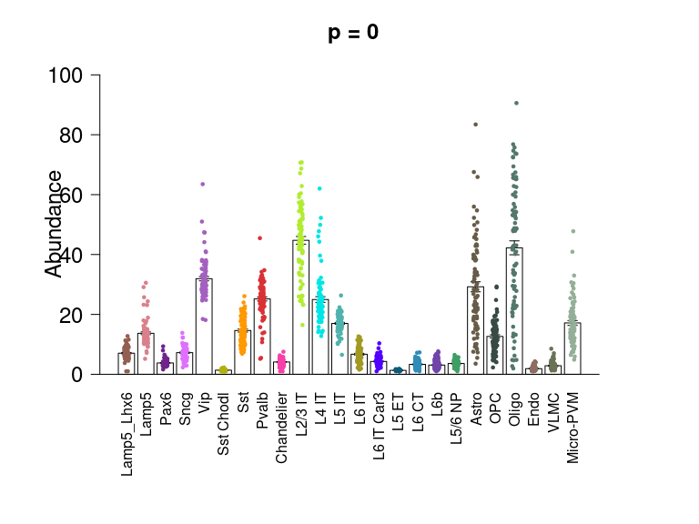

```r
vectorAbundance <- unlist(data.frame(cellCountsN[seaad_donors,]))
vectorSubclass  <- NULL
for (s in subclasses) vectorSubclass <- c(vectorSubclass,rep(s,length(seaad_donors)))
vectorCols <- type_info$subclass_color[match(vectorSubclass,type_info$subclass_label)]
vectorSubclass <- factor(vectorSubclass,levels=subclasses)

plt <- as.ggplot(function(){
par(mar=c(10,5,5,5))
verboseBarplot(100*vectorAbundance+1,vectorSubclass,main="",ylab="Abundance",xlab="", ylim = c(0,100),
                 addScatterplot = TRUE, pch=19, pt.cex=0.5, pt.col = vectorCols, las=2, col="white")
})
plt
```

```r
ggsave("abundance_barplots_SEAAD.pdf", plot=plt, height = 6, width = 8)
```

Plot variation in gene counts across donors by subclass.

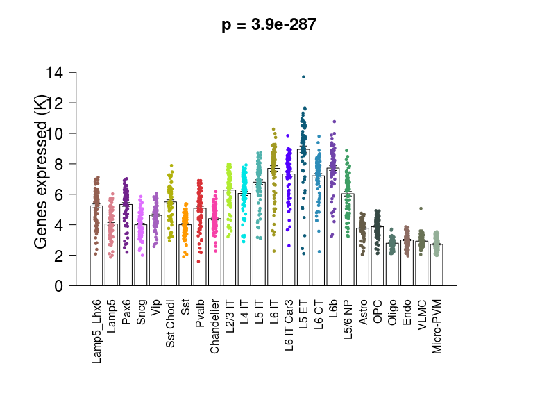

```r
vectorGenes <- unlist(data.frame(geneCounts[seaad_donors,]))

plt <- as.ggplot(function(){
par(mar=c(10,5,5,5))
verboseBarplot(vectorGenes/1000,vectorSubclass,main="",ylab="Genes expressed (K)",xlab="",ylim=c(0,15),
               addScatterplot = TRUE, pch=19, pt.cex=0.5, pt.col = vectorCols, las=2, col="white")
})
plt
```

```r
ggsave("gene_counts_barplots_SEAAD.pdf", plot=plt, height = 6, width = 8)
```

These values are much lower than for HVS. Since the values are calculated differently from the primary analysis and it’s not a key point of the paper, we do not pursue this analysis for the manuscript.

### Abundances and gene counts by class

For abundances let’s look at E/I ratios, since the fraction of non-neuronal cells was set based on FACS.

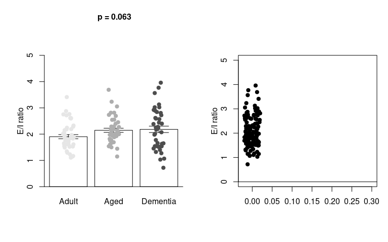

```r
## Section has been updated to compare HVS (MTG Ep only) vs. SEA-AD, separated by AD vs. control or ADNC

studyColors <- grey.colors(3)[3:1]

## Subset HVS donors only to donors from MTG that had epilepsy
mtg_ep_donors   <- hvs_donors[(donor_metadata[hvs_donors,]$ROI=="MTG")&
                                       (donor_metadata[hvs_donors,]$Disease=="Epilepsy")]
seaad_CT_donors <- intersect(seaad_donors,seaad_metadata2$`Donor ID`[seaad_metadata2$`Cognitive Status`=="No dementia"])
seaad_AD_donors <- intersect(seaad_donors,seaad_metadata2$`Donor ID`[seaad_metadata2$`Cognitive Status`=="Dementia"])
seaad_AD_donors <- setdiff(seaad_AD_donors,c("H21.33.020","H20.33.038")) # Exclude 2 donors with 259/260 neurons (all others have >1000)
run_donors <- c(mtg_ep_donors,seaad_CT_donors,seaad_AD_donors)

allGroupsDR <- c(rep("Adult",length(mtg_ep_donors)),rep("Aged",length(seaad_CT_donors)),rep("Dementia",length(seaad_AD_donors)))

EI <- NULL
for (l in run_donors)
  EI <- c(EI,sum(cellCounts[l,classGroups[[2]]])/sum(cellCounts[l,classGroups[[1]]]))
names(EI) <- run_donors

# Make plots
plt <- as.ggplot(function(){
par(mfrow=c(1,2))
par(mar=c(8,4,8,1))
verboseBarplot(EI[run_donors],allGroupsDR,main="",ylab="E/I ratio", xlab="",ylim=c(0,5),
               addScatterplot = TRUE, pch=19, pt.cex=1, cex.lab=1, cex.axis = 1,
               cex.main = 1, pt.col = studyColors[as.factor(allGroupsDR)], col="white")
set.seed(3)
plot(x=jitter(rep(0,length(EI))), EI, main="",ylab="E/I ratio",ylim=c(0,5),pch=19,
     xlab="",cex.lab=1, xlim=c(-0.022,0.3))
abline(h=0)
})
plt
```

```r
ggsave("EI_ratio_plots_SEAAD.pdf", plot=plt, height = 6, width = 8)
```

Potentially a minor increase in E/I ratio (e.g., fewer interneurons) and increased variability from Adult to age to dementia, however nothing reaches statistical significance.

## Neurosurgical vs. SEA-AD comparisons

In this section we’ll assess subclass variation in neurosurgical tissue and compare it to aged donors from the SEA-AD cohort… for which tissue source is it higher? How does it differ by subclass? For this analysis we limit ourselves to the 45 HVS donors with epilepsy from MTG to decrease variation associated with donor metadata and try to focus mostly on neurosurgical vs. SEA-AD (which is also MTG). We will use two methods for defining variation: (1) coefficient of variation (sd/mean) and (2) interquartile range / median. In both cases the idea is to define the spread of the distributions. In this case, we also divide SEA-AD donors by dementia vs. no dementia (or ADNC).

```r
# seaad_donors defined above.  For these plots, no need to separate out aged donors by disease status
ns_counts  <- cellCountsN[mtg_ep_donors,]
ct_counts  <- cellCountsN[seaad_CT_donors,]  # to avoid rewriting the code, we use "pm" for aged donors as well here.
ad_counts  <- cellCountsN[seaad_AD_donors,]

ns_mean <- apply(ns_counts,2,mean,na.rm=TRUE)
ns_COV  <- apply(ns_counts,2,sd,na.rm=TRUE)/ns_mean
ns_IQR  <- apply(ns_counts,2,IQR,na.rm=TRUE)/apply(ns_counts,2,median,na.rm=TRUE)

ct_mean <- apply(ct_counts,2,mean,na.rm=TRUE)
ct_COV  <- apply(ct_counts,2,sd,na.rm=TRUE)/ct_mean
ct_IQR  <- apply(ct_counts,2,IQR,na.rm=TRUE)/apply(ct_counts,2,median,na.rm=TRUE)

ad_mean <- apply(ad_counts,2,mean,na.rm=TRUE)
ad_COV  <- apply(ad_counts,2,sd,na.rm=TRUE)/ad_mean
ad_IQR  <- apply(ad_counts,2,IQR,na.rm=TRUE)/apply(ad_counts,2,median,na.rm=TRUE)
```

Now let’s plot the results.

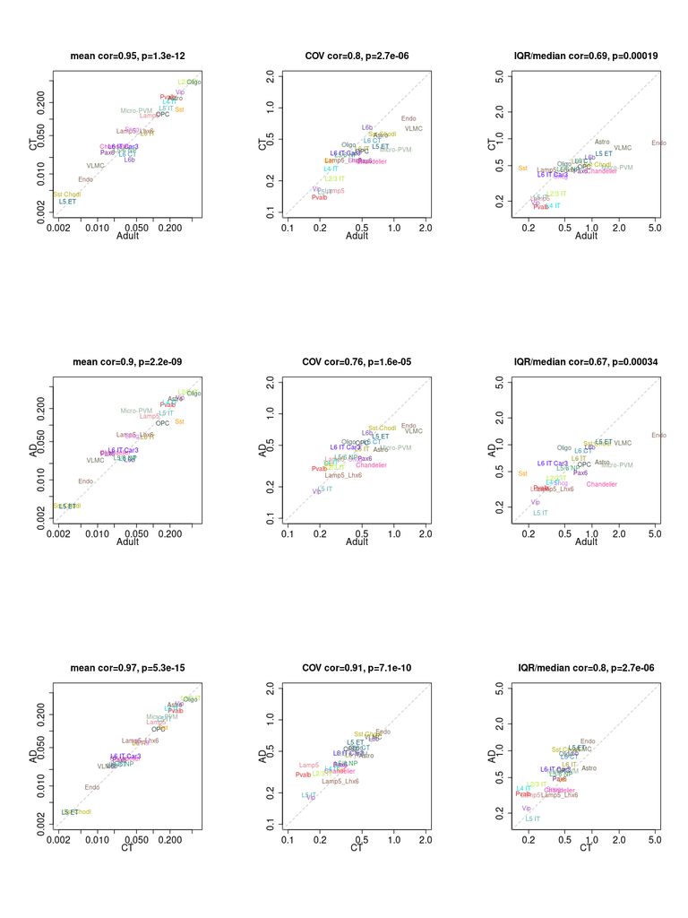

```r
# NOTE: I might need to manually adjust the xlim and ylim values below
plot_tmp <- function(x,y,s,text.col="black",xlab="Aged donors (MTG)",ylab="Neurosurgical (MTG, epilepsy)", xyline=TRUE, ...){
  verboseScatterplot(x,y,col="white",xlab=xlab,ylab=ylab,...)
  if(xyline) abline(0,1,col="grey",lty="dashed")
  text(x,y,s,col=text.col)
}

plt <- as.ggplot(function(){
par(mfrow=c(3,3))
plot_tmp(ns_mean,ct_mean,subclasses,subclass_colors,main="mean",log="xy",xlim=c(0.002,0.6),ylim=c(0.002,0.6),ylab="CT",xlab="Adult")
plot_tmp(ns_COV,ct_COV,subclasses,subclass_colors,main="COV",log="xy",xlim=c(0.1,2),ylim=c(0.1,2),ylab="CT",xlab="Adult")
plot_tmp(ns_IQR,ct_IQR,subclasses,subclass_colors,main="IQR/median",log="xy",xlim=c(0.15,5),ylim=c(0.15,5),ylab="CT",xlab="Adult")
plot_tmp(ns_mean,ad_mean,subclasses,subclass_colors,main="mean",log="xy",xlim=c(0.002,0.6),ylim=c(0.002,0.6),ylab="AD",xlab="Adult")
plot_tmp(ns_COV,ad_COV,subclasses,subclass_colors,main="COV",log="xy",xlim=c(0.1,2),ylim=c(0.1,2),ylab="AD",xlab="Adult")
plot_tmp(ns_IQR,ad_IQR,subclasses,subclass_colors,main="IQR/median",log="xy",xlim=c(0.15,5),ylim=c(0.15,5),ylab="AD",xlab="Adult")
plot_tmp(ct_mean,ad_mean,subclasses,subclass_colors,main="mean",log="xy",xlim=c(0.002,0.6),ylim=c(0.002,0.6),ylab="AD",xlab="CT")
plot_tmp(ct_COV,ad_COV,subclasses,subclass_colors,main="COV",log="xy",xlim=c(0.1,2),ylim=c(0.1,2),ylab="AD",xlab="CT")
plot_tmp(ct_IQR,ad_IQR,subclasses,subclass_colors,main="IQR/median",log="xy",xlim=c(0.15,5),ylim=c(0.15,5),ylab="AD",xlab="CT")
})
plt
```

```r
ggsave("variance_comparison_NSvsSEAAD.pdf", plot=plt, height = 16, width = 12)
```

Plot a different way.

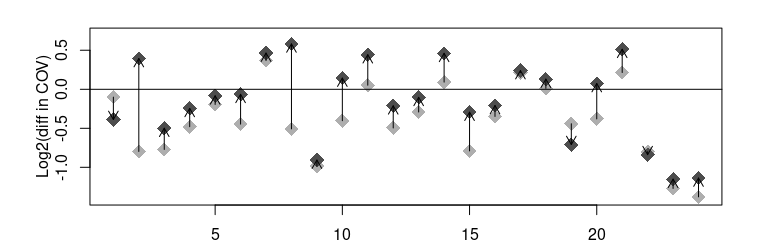

```r
studyColors <- grey.colors(3)[3:1]
lct <- log2(ct_COV/ns_COV)
lad <- log2(ad_COV/ns_COV)

plt <- as.ggplot(function(){
plot(lct, col = studyColors[2], pch=18,cex=2,ylim=c(-1.4,0.7),xlab="",ylab="Log2(diff in COV)")
points(lad, col = studyColors[3], pch=18,cex=2)
abline(h=0)
for (i in 1:length(lad)){
  arrows(i,lct[i],i,lad[i],length=0.1)
}
})
plt
```

```r
ggsave("variance_comarisons_NSvsSEAAD.pdf", plot=plt, height = 2.5, width = 8)
```

Overall, good agreement between categories for mean expression. However, there is more variation in neurosurgical cases (even after restriction to epilepsy cases in MTG) than in aged non-demented donors, likely reflecting the a combination of mostly technical and possibly biological factors discussed in the manuscript. However, there is a clear increase in abundance variation in demented cases vs. non-demented controls.

Now let’s visualize this by subclass.

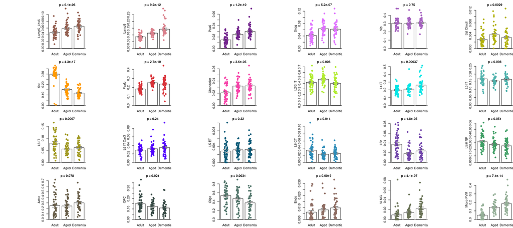

```r
countsME <- cellCountsN[run_donors,]

plt <- as.ggplot(function(){
par(mfrow=c(4,6))
par(mar=c(2,5,2,0))
for (s in subclasses)
  verboseBarplot(countsME[,s],allGroupsDR,main="",ylab=s,xlab="",
                 ylim = c(0,max(countsME[,s])),col="white",pt.col = subclass_colors[s],
                 addScatterplot = TRUE, pch=19, pt.cex=1, cex.lab=1, cex.axis = 1, cex.main = 1)
})
plt
```

```r
ggsave("abundance_barplots_by_NSvsSEAAD.pdf", plot=plt, height = 8, width = 18)
```

Now let’s revisit gene expression changes. We can compare gene expression differences and see how these relate to what we published in Hodge et al 2019 (for L5 only). Let’s first plot the number of genes expressed per class in postmortem vs. neurosurgical, considering on MTG donors.

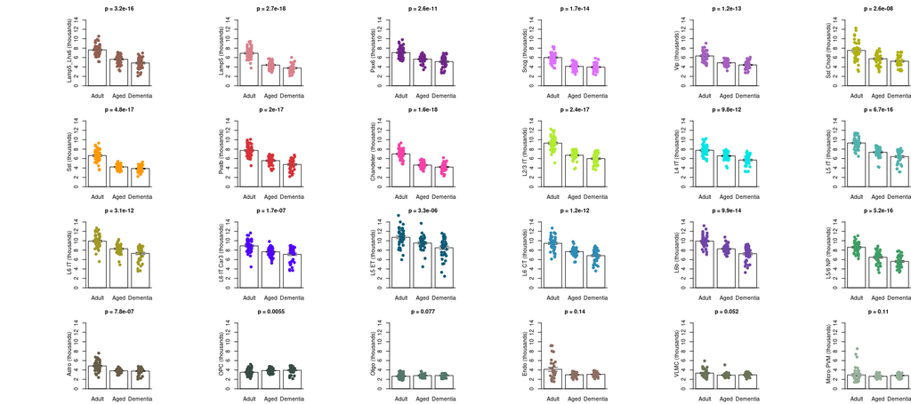

```r
geneCountsME <- geneCounts[run_donors,]

plt <- as.ggplot(function(){
par(mfrow=c(4,6))
par(mar=c(2,5,2,0))
for (s in subclasses)
  verboseBarplot(geneCountsME[,s]/1000,allGroupsDR,main="",ylab=paste(s,"(thousands)"),xlab="",
                 ylim = c(0,15),col="white",pt.col = subclass_colors[s],
                 addScatterplot = TRUE, pch=19, pt.cex=1, cex.lab=1, cex.axis = 1, cex.main = 1)
})
plt
```

```r
ggsave("geneCounts_barplots_by_NSvsSEAAD.pdf", plot=plt, height = 8, width = 18)
```

As above, I don’t think we can trust the comparison of number of genes expressed between adult and aged donors. However, most neurons have fewer genes expressed per cell type in donors with vs. donors without dementia, which is not surprising.

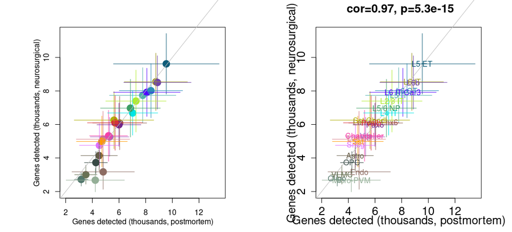

```r
df     = data.frame(X=colMeans(geneCountsME[cat=="PM",],na.rm=TRUE),errX=apply(geneCountsME[cat=="PM",],2,sd,na.rm=TRUE),
                    Y=colMeans(geneCountsME[cat=="NS",],na.rm=TRUE),errY=apply(geneCountsME[cat=="NS",],2,sd,na.rm=TRUE))/1000
rangeX = range(c(df$X + df$errX, df$X - df$errX))
rangeY = range(c(df$Y + df$errY, df$Y - df$errY))

plt <- as.ggplot(function(){
par(mfrow=c(1,2))
plot(df$X, df$Y, xlim = rangeX, ylim = rangeY,xlab="Genes detected (thousands, postmortem)",
     ylab="Genes detected (thousands, neurosurgical)",pch=19,cex=2,col=subclass_colors)
segments(df$X, df$Y - df$errY, df$X, df$Y + df$errY,col=subclass_colors)
segments(df$X - df$errX, df$Y, df$X + df$errX, df$Y,col=subclass_colors)
abline(0,1,col="grey")

verboseScatterplot(df$X, df$Y, xlim = rangeX, ylim = rangeY,xlab="Genes detected (thousands, postmortem)",
     ylab="Genes detected (thousands, neurosurgical)",pch=19,cex=0.25,col=subclass_colors)
segments(df$X, df$Y - df$errY, df$X, df$Y + df$errY,col=subclass_colors)
segments(df$X - df$errX, df$Y, df$X + df$errX, df$Y,col=subclass_colors)
abline(0,1,col="grey")
text(df$X, df$Y, subclasses,col=subclass_colors)
})
plt
```

```r
ggsave("geneCounts_means_scatterplots_by_NSvsSEAAD.pdf", plot=plt, height = 5, width = 11)
```

Compare the variation in neurosurgical vs. postmortem tissues.

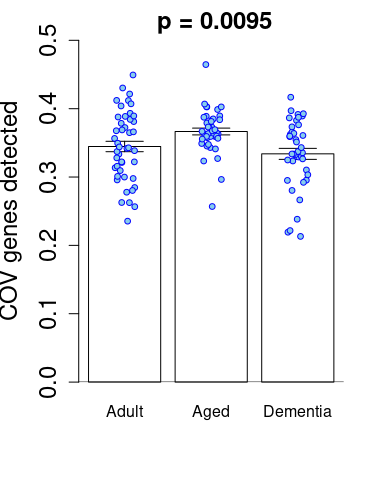

```r
x = apply(geneCountsME,1,sd,na.rm=TRUE)/apply(geneCountsME,1,mean,na.rm=TRUE)
verboseBarplot(x,allGroupsDR,xlab="",ylab="COV genes detected",col="white",addScatterplot = TRUE, ylim=c(0,0.5))
```

The variation in number of genes expressed per cell is highest in aged, non-demented donors, although these distributions are quite overlapping. I think additional work (outside the scope of present efforts) would be needed to appropriately interpret this result.

## High variance genes in aged vs. adult donors

This section is aimed at identifying the genes with strong donor signatures. More specifically, we seek to ask which genes have variance that is highly donor-dependent (e.g., random cell pairs from different donors are more variable than pairs of cells from the same donor), rather than strictly defining variance of a given gene. This analysis repeats the gene variance analysis from figure 1, considering only patients with epilepsy in MTG and comparing the results to those from SEA-AD cases with and without dementia. Since my R instance is unable to handle reading in the complete SEA data from AWS, instead I use the cellxgene files above, which are separated by subclass.

Start by calculating expressed genes in the HVS data set. As a start, we’ll choose the ones that are expressed only in the HVS data and that are also included in the SEA-AD transcriptome, but we might need to also filter for ones expressed in SEA-AD for a fair comparison We will use these genes for HVS and SEA-AD.

```r
# Find cell type genes
cellsPerPermutation  = 24
kpGn <- list()
for (ct in subclasses){
  tmpSamp    <- subsampleCells(seurat_all[[ct]]$donor_name,cellsPerPermutation)&is.element(seurat_all[[ct]]$donor_name,mtg_ep_donors)
  # Speed up quantile calculation and make it fairer by subsampling by donor (above) and by using fnth function from collapse library
  kpGn[[ct]] <- fnth(t(as.matrix(seurat_all[[ct]]@assays$RNA@data[,tmpSamp])),n=0.75)>0
  # Include genes expressed in >25% of cells
  kpGn[[ct]][!is.element(names(kpGn[[ct]]),genesSEAAD)] = FALSE
  print(paste0(ct,": ",sum(kpGn[[ct]])," variable genes."))
}
```

```
[1] "Lamp5_Lhx6: 6803 variable genes."
[1] "Lamp5: 6219 variable genes."
[1] "Pax6: 6304 variable genes."
[1] "Sncg: 5445 variable genes."
[1] "Vip: 5746 variable genes."
[1] "Sst Chodl: 7313 variable genes."
[1] "Sst: 6031 variable genes."
[1] "Pvalb: 6888 variable genes."
[1] "Chandelier: 6278 variable genes."
[1] "L2/3 IT: 8037 variable genes."
[1] "L4 IT: 6848 variable genes."
[1] "L5 IT: 8029 variable genes."
[1] "L6 IT: 8573 variable genes."
[1] "L6 IT Car3: 7760 variable genes."
[1] "L5 ET: 9125 variable genes."
[1] "L6 CT: 8160 variable genes."
[1] "L6b: 8548 variable genes."
[1] "L5/6 NP: 7587 variable genes."
[1] "Astro: 4370 variable genes."
[1] "OPC: 3162 variable genes."
[1] "Oligo: 2447 variable genes."
[1] "Endo: 3821 variable genes."
[1] "VLMC: 2808 variable genes."
[1] "Micro-PVM: 2159 variable genes."
```

### HVS data analysis

Perform the calculate of gene variance and collect relevant variables from the 45 epilepsy donors from MTG. (This is a long code block.)

```r
# Variable set up
cellsPerSubclass <- 4500 # Average of ~100 cell pairs per donor
gene_variances   <- gene_variances_permuted <- gene_diffs <- gene_diffs_permuted <- list()

# Calculate differences between pairs of cells and associate variation of these differences
print(paste(date(),"- start"))
```

```
[1] "Fri Dec 16 12:35:23 2022 - start"
```

```r
for (ct in subclasses){
  tb        <- table(seurat_all[[ct]]$donor_name)
  tmpDonors <- intersect(mtg_ep_donors,names(tb)[tb>=4])
  tmpSamp   <- is.element(seurat_all[[ct]]$donor_name,tmpDonors)
  set.seed(which(subclasses==ct))
  donor1    <- sample(tmpDonors,cellsPerSubclass*3,replace=TRUE)
  set.seed(which(subclasses==ct)+1)
  donor2    <- sample(tmpDonors,cellsPerSubclass*3,replace=TRUE)
  kpTmp     <- donor1!=donor2
  donor1    <- donor1[kpTmp][1:cellsPerSubclass]
  donor2    <- donor2[kpTmp][1:cellsPerSubclass]
  cell1a <- cell1b <- cell2a <- NULL
  for (z in 1:cellsPerSubclass){
    c1a    <- sample(which(seurat_all[[ct]]$donor_name==donor1[z]),1)
    cell1a <- c(cell1a,c1a)
    cell1b <- c(cell1b,sample(which((seurat_all[[ct]]$donor_name==donor1[z])&((1:length(seurat_all[[ct]]$donor_name))!=c1a)),1))
    cell2a <- c(cell2a,sample(which(seurat_all[[ct]]$donor_name==donor2[z]),1))
  }

  # Remove duplicates
  firstOne   <- match(unique(cell1a*(cell1b/7)^2),cell1a*(cell1b/7)^2)
  countFirst <- length(firstOne)

  datTmp     <- seurat_all[[ct]]@assays$RNA@data[kpGn[[ct]],c(cell1a[firstOne],cell1b[firstOne],cell2a[firstOne])]
  gene_diffs[[ct]]          <- abs(datTmp[,(1:countFirst)]-datTmp[,(countFirst+1):(2*countFirst)])
  gene_diffs_permuted[[ct]] <- abs(datTmp[,(1:countFirst)]-datTmp[,(2*countFirst+1):(3*countFirst)])
  gene_variances[[ct]]          <- t(fvar(t(as.matrix(gene_diffs[[ct]])),rep("All",countFirst)))
  gene_variances_permuted[[ct]] <- t(fvar(t(as.matrix(gene_diffs_permuted[[ct]])),rep("All",countFirst)))
  print(paste("Cell count:",ct,"=",dim(gene_diffs[[ct]])[2]))
  collectGarbage()
}
```

```
[1] "Cell count: Lamp5_Lhx6 = 4352"
[1] "Cell count: Lamp5 = 4437"
[1] "Cell count: Pax6 = 3305"
[1] "Cell count: Sncg = 4282"
[1] "Cell count: Vip = 4497"
[1] "Cell count: Sst Chodl = 597"
[1] "Cell count: Sst = 4411"
[1] "Cell count: Pvalb = 4491"
[1] "Cell count: Chandelier = 3715"
[1] "Cell count: L2/3 IT = 4498"
[1] "Cell count: L4 IT = 4497"
[1] "Cell count: L5 IT = 4499"
[1] "Cell count: L6 IT = 4449"
[1] "Cell count: L6 IT Car3 = 4307"
[1] "Cell count: L5 ET = 1666"
[1] "Cell count: L6 CT = 4271"
[1] "Cell count: L6b = 4344"
[1] "Cell count: L5/6 NP = 4394"
[1] "Cell count: Astro = 4452"
[1] "Cell count: OPC = 4441"
[1] "Cell count: Oligo = 4471"
[1] "Cell count: Endo = 1671"
[1] "Cell count: VLMC = 2181"
[1] "Cell count: Micro-PVM = 4057"
```

```r
print(paste(date(),"- end"))
```

```
[1] "Fri Dec 16 13:04:46 2022 - end"
```

```r
print("Now summarize these values between matched and distinct donors.")
```

```
[1] "Now summarize these values between matched and distinct donors."
```

```r
variance_stats_hvs <- list()
for (ct in subclasses){
  out  <- t(apply(cbind(gene_diffs_permuted[[ct]],gene_diffs[[ct]]),1,getStats))
  out  <- cbind(out,p.adjust(out[,6],"BH")) # Define FDR corrected p-values  # qvalue(out[,6])$qvalue)#
  colnames(out) <- c("permuted_var","actual_var","permuted_var_sd",
                       "actual_var_sd","Tstat","Pvalue","FDR_Pvalue")
  variance_stats_hvs[[ct]] <- as.data.frame(out)
}
print("Summarization complete.")
```

```
[1] "Summarization complete."
```

Which genes (and how many) per subclass are significant in each direction after FDR correction?

```r
## Dynamic selection of threshold to ensure no random genes
thresh = 1
for (ct in subclasses)
  thresh=min(c(thresh,variance_stats_hvs[[ct]]$FDR_Pvalue[variance_stats_hvs[[ct]]$Tstat<0]))
print(paste("Dynamic threshold (HVS):",signif(thresh,3)))
```

```
[1] "Dynamic threshold (HVS): 0.00742"
```

```r
varGenes_hvs <- NULL

for (ct in subclasses){
  tmp  <- abs(10*(variance_stats_hvs[[ct]]$Tstat<0)+(variance_stats_hvs[[ct]]$FDR_Pvalue<thresh)-5)-3
  out  <- data.frame(gene=rownames(variance_stats_hvs[[ct]]),direction=c("high","NS","low")[tmp],subclass=ct)
  varGenes_hvs <- rbind(varGenes_hvs,out)
}

## Output the genes to a table
write.csv(varGenes_hvs,"variable_genes_hvsEp.csv",row.names = FALSE)

## Write counts to screen
data.frame(table(varGenes_hvs$subclass[varGenes_hvs$direction=="high"]))
```

| Var1 | Freq |
| --- | --- |
| Astro | 1842 |
| Chandelier | 499 |
| Endo | 383 |
| L2/3 IT | 2893 |
| L4 IT | 1636 |
| L5 ET | 1032 |
| L5 IT | 1914 |
| L5/6 NP | 967 |
| L6 CT | 3645 |
| L6 IT | 2850 |

[output cut: 14 more lines]

### SEA-AD data analysis

Perform the calculate of gene variance and collect relevant variables from the 84 SEA-AD donors from MTG. Note the first step of reading in a table that links file names from cellxgene with subclass name. Also note that we overwrite the data at each iteration of the subclass to save memory. Also note that we read in the data using a different function.  
**Note: you may need to change all instances of `Donor ID` and `Donor.ID` below to `donor_id` before running.** **Note: the index of the sparse matrix for L2/3 IT is larger than the max number storable in a 32-bit integer, which means that it is not possible to read this file into R, so all values get read in as “0”. For a more careful analysis, python will need to be used.**

```r
# Read in file conversion table
convert <- read.csv("CZI_file_names.csv",row.names=1)

# Variable setup
gene_variancesCT <- gene_variances_permutedCT <- gene_diffsCT <- gene_diffs_permutedCT <- list()
gene_variancesAD <- gene_variances_permutedAD <- gene_diffsAD <- gene_diffs_permutedAD <- list()

# Calculate differences between pairs of cells and associate variation of these differences
print(paste(date(),"- start"))
```

```
[1] "Fri Dec 16 13:07:51 2022 - start"
```

```r
for (ct in subclasses){
  print(paste("========== Starting",ct,"=========="))
  # Read in the cellxgene table for this subclass
  fn     <- paste0("CZI/",convert[ct,])
  dataIn <- readH5AD(fn)
  countsTmp <- assay(dataIn,"X")
  rownames(countsTmp) <- genesSEAAD
  seu <- CreateSeuratObject(counts=countsTmp)  # seu is the seurat object with the data
  met <- as.data.frame(colData(dataIn))
  seu <- AddMetaData(seu,met)

  # Subset to relevant CT and AD cells
  keep_sub  <- keep_seaad&(seaad_metadata2$Subclass==ct)&is.element(seaad_metadata2$`Donor ID`,seaad_CT_donors)
  samplesCT <- seaad_metadata2$sample_id[keep_sub]  # CONFIRM CORRECT IDS, then apply the cell sampling AFTER this step
  keep_sub  <- keep_seaad&(seaad_metadata2$Subclass==ct)&is.element(seaad_metadata2$`Donor ID`,seaad_AD_donors)
  samplesAD <- seaad_metadata2$sample_id[keep_sub]  # CONFIRM CORRECT IDS, then apply the cell sampling AFTER this step
  seuCT <- seu[,samplesCT]
  seuCT <- SetAssayData(seuCT,new.data=logCPM(seuCT@assays$RNA@counts),slot="data")
  seuAD <- seu[,samplesAD]
  seuAD <- SetAssayData(seuAD,new.data=logCPM(seuAD@assays$RNA@counts),slot="data")

  # Clear memory
  rm(seu, dataIn, countsTmp)
  collectGarbage()

  # Find gene information for SEA-AD donors without dementia
  tb        <- table(seuCT$Donor.ID)
  tmpDonors <- names(tb)[tb>=4]
  tmpSamp   <- is.element(seuCT$Donor.ID,tmpDonors)
  set.seed(which(subclasses==ct))
  donor1    <- sample(tmpDonors,cellsPerSubclass*3,replace=TRUE)
  set.seed(which(subclasses==ct)+1)
  donor2    <- sample(tmpDonors,cellsPerSubclass*3,replace=TRUE)
  kpTmp     <- donor1!=donor2
  donor1    <- donor1[kpTmp][1:cellsPerSubclass]
  donor2    <- donor2[kpTmp][1:cellsPerSubclass]
  cell1a <- cell1b <- cell2a <- NULL
  for (z in 1:cellsPerSubclass){
    c1a    <- sample(which(seuCT$Donor.ID==donor1[z]),1)
    cell1a <- c(cell1a,c1a)
    cell1b <- c(cell1b,sample(which((seuCT$Donor.ID==donor1[z])&((1:length(seuCT$Donor.ID))!=c1a)),1))
    cell2a <- c(cell2a,sample(which(seuCT$Donor.ID==donor2[z]),1))
  }
  firstOne   <- match(unique(cell1a*(cell1b/7)^2),cell1a*(cell1b/7)^2)
  countFirst <- length(firstOne)
  gn         <- names(kpGn[[ct]])[kpGn[[ct]]]
  datTmp     <- seuCT@assays$RNA@data[gn,c(cell1a[firstOne],cell1b[firstOne],cell2a[firstOne])]
  gene_diffsCT[[ct]]          <- abs(datTmp[,(1:countFirst)]-datTmp[,(countFirst+1):(2*countFirst)])
  gene_diffs_permutedCT[[ct]] <- abs(datTmp[,(1:countFirst)]-datTmp[,(2*countFirst+1):(3*countFirst)])
  gene_variancesCT[[ct]]          <- t(fvar(t(as.matrix(gene_diffsCT[[ct]])),rep("All",countFirst)))
  gene_variances_permutedCT[[ct]] <- t(fvar(t(as.matrix(gene_diffs_permutedCT[[ct]])),rep("All",countFirst)))
  print(paste("Cell count (CT):",ct,"=",dim(gene_diffsCT[[ct]])[2]))

  # Find gene information for SEA-AD donors with dementia
  tb        <- table(seuAD$Donor.ID)
  tmpDonors <- names(tb)[tb>=4]
  tmpSamp   <- is.element(seuAD$Donor.ID,tmpDonors)
  set.seed(which(subclasses==ct))
  donor1    <- sample(tmpDonors,cellsPerSubclass*3,replace=TRUE)
  set.seed(which(subclasses==ct)+1)
  donor2    <- sample(tmpDonors,cellsPerSubclass*3,replace=TRUE)
  kpTmp     <- donor1!=donor2
  donor1    <- donor1[kpTmp][1:cellsPerSubclass]
  donor2    <- donor2[kpTmp][1:cellsPerSubclass]
  cell1a <- cell1b <- cell2a <- NULL
  for (z in 1:cellsPerSubclass){
    c1a    <- sample(which(seuAD$Donor.ID==donor1[z]),1)
    cell1a <- c(cell1a,c1a)
    cell1b <- c(cell1b,sample(which((seuAD$Donor.ID==donor1[z])&((1:length(seuAD$Donor.ID))!=c1a)),1))
    cell2a <- c(cell2a,sample(which(seuAD$Donor.ID==donor2[z]),1))
  }
  firstOne   <- match(unique(cell1a*(cell1b/7)^2),cell1a*(cell1b/7)^2)
  countFirst <- length(firstOne)
  gn         <- names(kpGn[[ct]])[kpGn[[ct]]]
  datTmp     <- seuAD@assays$RNA@data[gn,c(cell1a[firstOne],cell1b[firstOne],cell2a[firstOne])]
  gene_diffsAD[[ct]]          <- abs(datTmp[,(1:countFirst)]-datTmp[,(countFirst+1):(2*countFirst)])
  gene_diffs_permutedAD[[ct]] <- abs(datTmp[,(1:countFirst)]-datTmp[,(2*countFirst+1):(3*countFirst)])
  gene_variancesAD[[ct]]          <- t(fvar(t(as.matrix(gene_diffsAD[[ct]])),rep("All",countFirst)))
  gene_variances_permutedAD[[ct]] <- t(fvar(t(as.matrix(gene_diffs_permutedAD[[ct]])),rep("All",countFirst)))
  print(paste("Cell count (AD):",ct,"=",dim(gene_diffsAD[[ct]])[2]))

  # Clear memory
  rm(seuCT, setAD, datTmp)
  collectGarbage()
}
```

```
[1] "========== Starting Lamp5_Lhx6 =========="
```

```
[1] "Cell count (CT): Lamp5_Lhx6 = 4494"
[1] "Cell count (AD): Lamp5_Lhx6 = 4467"
[1] "========== Starting Lamp5 =========="
```

```
[1] "Cell count (CT): Lamp5 = 4495"
[1] "Cell count (AD): Lamp5 = 4495"
[1] "========== Starting Pax6 =========="
```

```
[1] "Cell count (CT): Pax6 = 4466"
[1] "Cell count (AD): Pax6 = 4355"
[1] "========== Starting Sncg =========="
```

```
[1] "Cell count (CT): Sncg = 4466"
[1] "Cell count (AD): Sncg = 4423"
[1] "========== Starting Vip =========="
```

```
[1] "Cell count (CT): Vip = 4499"
[1] "Cell count (AD): Vip = 4500"
[1] "========== Starting Sst Chodl =========="
```

```
[1] "Cell count (CT): Sst Chodl = 3211"
[1] "Cell count (AD): Sst Chodl = 2599"
[1] "========== Starting Sst =========="
```

```
[1] "Cell count (CT): Sst = 4499"
[1] "Cell count (AD): Sst = 4486"
[1] "========== Starting Pvalb =========="
```

```
[1] "Cell count (CT): Pvalb = 4499"
[1] "Cell count (AD): Pvalb = 4496"
[1] "========== Starting Chandelier =========="
```

```
[1] "Cell count (CT): Chandelier = 4454"
[1] "Cell count (AD): Chandelier = 4321"
[1] "========== Starting L2/3 IT =========="
```

```
[1] "Cell count (CT): L2/3 IT = 4500"
[1] "Cell count (AD): L2/3 IT = 4500"
[1] "========== Starting L4 IT =========="
```

```
[1] "Cell count (CT): L4 IT = 4500"
[1] "Cell count (AD): L4 IT = 4500"
[1] "========== Starting L5 IT =========="
```

```
[1] "Cell count (CT): L5 IT = 4500"
[1] "Cell count (AD): L5 IT = 4499"
[1] "========== Starting L6 IT =========="
```

```
[1] "Cell count (CT): L6 IT = 4497"
[1] "Cell count (AD): L6 IT = 4488"
[1] "========== Starting L6 IT Car3 =========="
```

```
[1] "Cell count (CT): L6 IT Car3 = 4492"
[1] "Cell count (AD): L6 IT Car3 = 4477"
[1] "========== Starting L5 ET =========="
```

```
[1] "Cell count (CT): L5 ET = 3615"
[1] "Cell count (AD): L5 ET = 3416"
[1] "========== Starting L6 CT =========="
```

```
[1] "Cell count (CT): L6 CT = 4479"
[1] "Cell count (AD): L6 CT = 4398"
[1] "========== Starting L6b =========="
```

```
[1] "Cell count (CT): L6b = 4431"
[1] "Cell count (AD): L6b = 4415"
[1] "========== Starting L5/6 NP =========="
```

```
[1] "Cell count (CT): L5/6 NP = 4487"
[1] "Cell count (AD): L5/6 NP = 4445"
[1] "========== Starting Astro =========="
```

```
[1] "Cell count (CT): Astro = 4482"
[1] "Cell count (AD): Astro = 4498"
[1] "========== Starting OPC =========="
```

```
[1] "Cell count (CT): OPC = 4409"
[1] "Cell count (AD): OPC = 4480"
[1] "========== Starting Oligo =========="
```

```
[1] "Cell count (CT): Oligo = 4499"
[1] "Cell count (AD): Oligo = 4480"
[1] "========== Starting Endo =========="
```

```
[1] "Cell count (CT): Endo = 3241"
[1] "Cell count (AD): Endo = 3270"
[1] "========== Starting VLMC =========="
```

```
[1] "Cell count (CT): VLMC = 4032"
[1] "Cell count (AD): VLMC = 4200"
[1] "========== Starting Micro-PVM =========="
```

```
[1] "Cell count (CT): Micro-PVM = 4489"
[1] "Cell count (AD): Micro-PVM = 4499"
```

```r
print(paste(date(),"- end"))
```

```
[1] "Fri Dec 16 15:30:12 2022 - end"
```

```r
print("Now summarize these values between matched and distinct donors.")
```

```
[1] "Now summarize these values between matched and distinct donors."
```

```r
variance_stats_CT <- variance_stats_AD <- list()
for (ct in subclasses){
  out  <- t(apply(cbind(gene_diffs_permutedCT[[ct]],gene_diffsCT[[ct]]),1,getStats))
  out  <- cbind(out,p.adjust(out[,6],"BH")) # Define FDR corrected p-values  # qvalue(out[,6])$qvalue)#
  colnames(out) <- c("permuted_var","actual_var","permuted_var_sd",
                       "actual_var_sd","Tstat","Pvalue","FDR_Pvalue")
  variance_stats_CT[[ct]] <- as.data.frame(out)

  out  <- t(apply(cbind(gene_diffs_permutedAD[[ct]],gene_diffsAD[[ct]]),1,getStats))
  out  <- cbind(out,p.adjust(out[,6],"BH")) # Define FDR corrected p-values  # qvalue(out[,6])$qvalue)#
  colnames(out) <- c("permuted_var","actual_var","permuted_var_sd",
                       "actual_var_sd","Tstat","Pvalue","FDR_Pvalue")
  variance_stats_AD[[ct]] <- as.data.frame(out)
}
print("Summarization complete.")
```

```
[1] "Summarization complete."
```

```r
save(gene_diffsCT, gene_diffs_permutedCT, gene_variancesCT, gene_variances_permutedCT,
     gene_diffsAD, gene_diffs_permutedAD, gene_variancesAD, gene_variances_permutedAD,
     gene_diffs, gene_diffs_permuted, gene_variances, gene_variances_permuted, file="gene_variances_info.RData")
```

### Count variable genes

Which genes (and how many) per subclass are significant in each direction after FDR correction?

```r
## Dynamic selection of threshold to ensure no random genes
thresh_hvs = 1
for (ct in subclasses)
  thresh_hvs=min(c(thresh_hvs,variance_stats_hvs[[ct]]$FDR_Pvalue[variance_stats_hvs[[ct]]$Tstat<0]))
print(paste("Dynamic threshold (HVS):",signif(thresh_hvs,3)))
```

```
[1] "Dynamic threshold (HVS): 0.00742"
```

```r
varGenes_hvs <- NULL

for (ct in subclasses){
  tmp  <- abs(10*(variance_stats_hvs[[ct]]$Tstat<0)+(variance_stats_hvs[[ct]]$FDR_Pvalue<thresh_hvs)-5)-3
  out  <- data.frame(gene=rownames(variance_stats_hvs[[ct]]),direction=c("high","NS","low")[tmp],subclass=ct)
  varGenes_hvs <- rbind(varGenes_hvs,out)
}

## Non-demented SEA-AD
thresh_CT = 1
for (ct in subclasses){
  variance_stats_CT[[ct]][is.na(variance_stats_CT[[ct]])] = 1
  thresh_CT=min(c(thresh_CT,variance_stats_CT[[ct]]$FDR_Pvalue[variance_stats_CT[[ct]]$Tstat<0]))
}
print(paste("Dynamic threshold (SEA-AD: non-demented):",signif(thresh_CT,3)))
```

```
[1] "Dynamic threshold (SEA-AD: non-demented): 0.0126"
```

```r
varGenes_CT <- NULL

for (ct in subclasses){
  tmp  <- abs(10*(variance_stats_CT[[ct]]$Tstat<0)+(variance_stats_CT[[ct]]$FDR_Pvalue<thresh_CT)-5)-3
  out  <- data.frame(gene=rownames(variance_stats_CT[[ct]]),direction=c("high","NS","low")[tmp],subclass=ct)
  varGenes_CT <- rbind(varGenes_CT,out)
}

## Demented SEA-AD
thresh_AD = 1
for (ct in subclasses){
  variance_stats_AD[[ct]][is.na(variance_stats_AD[[ct]])] = 1
  thresh_AD=min(c(thresh_AD,variance_stats_AD[[ct]]$FDR_Pvalue[variance_stats_AD[[ct]]$Tstat<0]))
}
print(paste("Dynamic threshold (SEA-AD: non-demented):",signif(thresh_AD,3)))
```

```
[1] "Dynamic threshold (SEA-AD: non-demented): 0.0115"
```

```r
varGenes_AD <- NULL

for (ct in subclasses){
  tmp  <- abs(10*(variance_stats_AD[[ct]]$Tstat<0)+(variance_stats_AD[[ct]]$FDR_Pvalue<thresh_AD)-5)-3
  out  <- data.frame(gene=rownames(variance_stats_AD[[ct]]),direction=c("high","NS","low")[tmp],subclass=ct)
  varGenes_AD <- rbind(varGenes_AD,out)
}

## Write counts to screen
cnts <- data.frame(adult=table(factor(varGenes_hvs$subclass[varGenes_hvs$direction=="high"],levels=subclasses)),
           nondemented=table(factor(varGenes_CT$subclass[varGenes_CT$direction=="high"],levels=subclasses)),
           demented=table(factor(varGenes_AD$subclass[varGenes_AD$direction=="high"],levels=subclasses)))
cnts <- as.matrix(cnts[,c(2,4,6)])
rownames(cnts) <- subclasses
colnames(cnts) <- c("adult","aged","dementia")
cnts
```

```
           adult aged dementia
Lamp5_Lhx6  1186 1181     3751
Lamp5       1267  723     1039
Pax6         587  335     1925
Sncg         599  426      234
Vip          592   91      165
Sst Chodl    230 1160      336
Sst         1152  135      175
Pvalb        994  731     3005
Chandelier   499  229     1058
L2/3 IT     2893    0        0
L4 IT       1636  768     3176
L5 IT       1914 1102     5015
L6 IT       2850 1349     6168
L6 IT Car3  2260 1194     5251
L5 ET       1032 2481     6170
L6 CT       3645  657     4319
L6b         2907  747     5432
L5/6 NP      967 4180     3240
Astro       1842  362     1156
OPC          538  247      530
Oligo        592  116       90
Endo         383  210      176
VLMC         466   99      161
Micro-PVM   1335  181      204
```

```r
## Output the genes to a table
write.csv(cnts,"variable_gene_counts.csv",row.names = FALSE)
```

Plot this table.

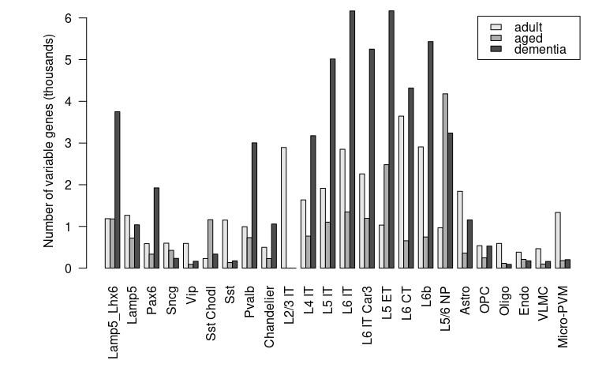

```r
studyColors <- grey.colors(3)[3:1]
plt <- as.ggplot(function(){
par(mar=c(10,5,1,1))
barplot(t(cnts)/1000,beside = TRUE,las=2,legend=TRUE, ylab="Number of variable genes (thousands)", col=studyColors)
})
plt
```

```r
ggsave("variable_gene_counts_NSandSEAAD.pdf", plot=plt, height = 5, width = 8)
```

What if we scale by the number of expressed genes, since non-neuronal types generally have fewer genes expressed?

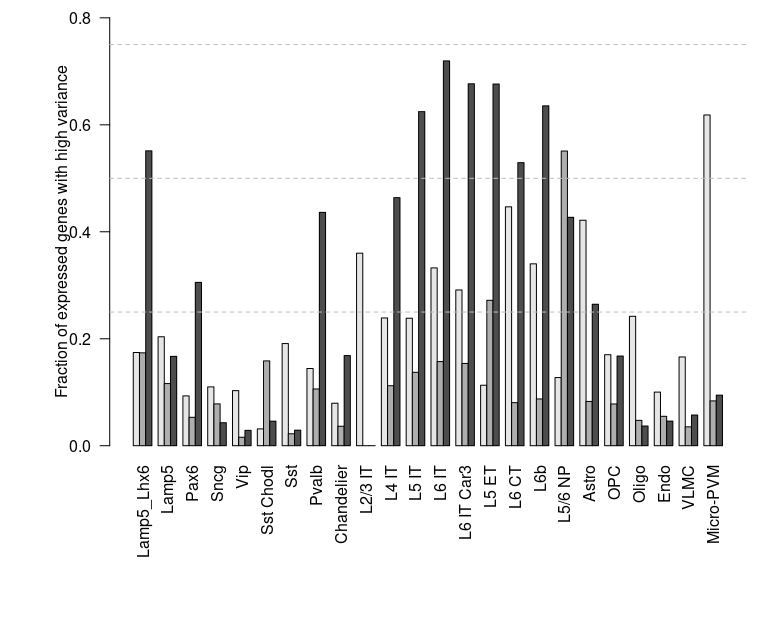

```r
geneCountPerSubclass <- cbind(table(varGenes_hvs$subclass)[subclasses],
                              table(varGenes_CT$subclass)[subclasses],
                              table(varGenes_AD$subclass)[subclasses])

plt <- as.ggplot(function(){
par(mar=c(10,5,1,1))
barplot(t(cnts/geneCountPerSubclass),las=2,xlab="",beside = TRUE,las=2,ylim=c(0,0.8),
        ylab="Fraction of expressed genes with high variance", col=studyColors)
abline(h=c(0.25,0.5,0.75),lty="dashed",col="grey")
})
plt
```

```r
ggsave("variance_gene_fraction_barplot_NSandSEAAD.pdf", plot=plt, height = 6.5, width = 9)
```

Some key takeaways: (1) There is generally higher variability in data from this study than in SEA-AD data from non-demented aged donors; (2) Aged donors with dementia have substantially more variable genes than those without dementia; (3) Generally much less variability in SEA-AD for glial than reported here (although in both astrocyte have the largest number of genes in the glial types) and (4) results of high glutamatergic variability agree between studies.

### Find common and distinct genes

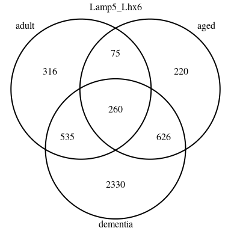

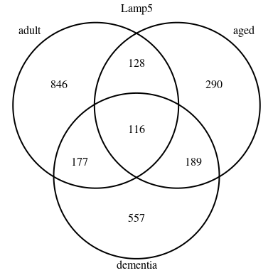

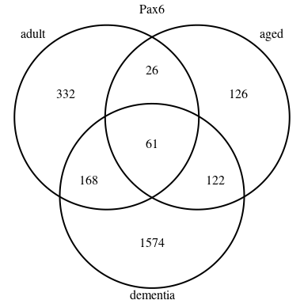

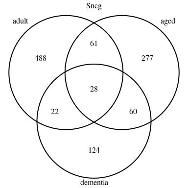

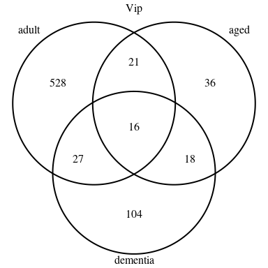

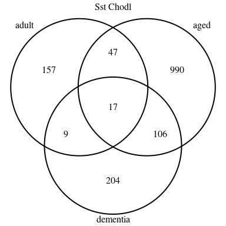

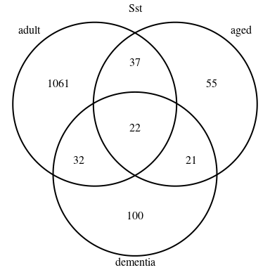

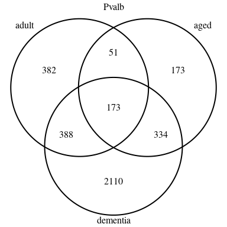

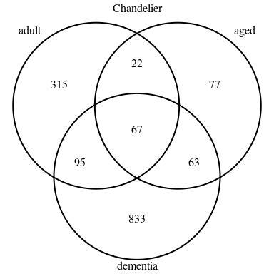

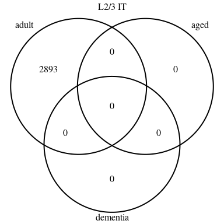

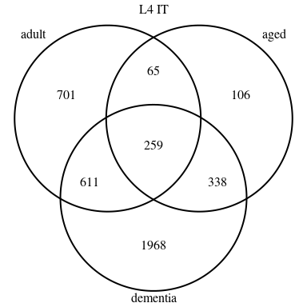

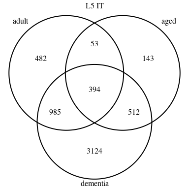

[12 more figures not shown]

```r
print.ggExtraPlot <- function(x, newpage = is.null(vp), vp = NULL,...) {
  if (newpage) grid::grid.newpage()
  grid::grid.draw(x)
}
for (ct in subclasses){
  geneList <- list(adult=varGenes_hvs$gene[(varGenes_hvs$subclass==ct)&(varGenes_hvs$direction=="high")],
                   aged=varGenes_CT$gene[(varGenes_CT$subclass==ct)&(varGenes_CT$direction=="high")],
                   dementia=varGenes_AD$gene[(varGenes_AD$subclass==ct)&(varGenes_AD$direction=="high")])
  print.ggExtraPlot(venn.diagram(geneList,filename=NULL,main=ct))
}
```

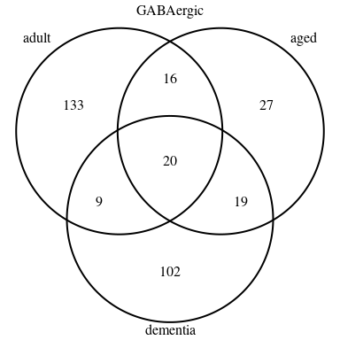

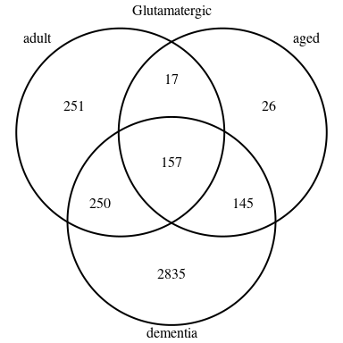

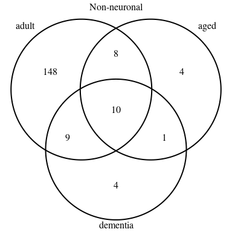

```r
varGenes_hvs2 <- varGenes_hvs
varGenes_hvs2$direction[varGenes_hvs2$subclass=="L2/3 IT"] = "NS"  # Since these were not readable in SEA-AD, we exclude these
varGene_classList <- list()
for (cl in sort(unique(classes))){
  adult_list <- varGenes_hvs2$gene[is.element(varGenes_hvs2$subclass,names(classes)[classes==cl])&(varGenes_hvs2$direction=="high")]
  adult_list <- names(table(adult_list))[table(adult_list)>=(sum(classes==cl)/1.5)]
  aged_list  <- varGenes_CT$gene[is.element(varGenes_CT$subclass,names(classes)[classes==cl])&(varGenes_CT$direction=="high")]
  aged_list  <- names(table(aged_list))[table(aged_list)>=(sum(classes==cl)/1.5)]
  dem_list   <- varGenes_AD$gene[is.element(varGenes_AD$subclass,names(classes)[classes==cl])&(varGenes_AD$direction=="high")]
  dem_list   <- names(table(dem_list))[table(dem_list)>=(sum(classes==cl)/1.5)]
  geneList   <- list(adult=adult_list, aged=aged_list, dementia=dem_list)
  varGene_classList[[cl]] <- geneList
  print.ggExtraPlot(venn.diagram(geneList,filename=NULL,main=cl))
}
```

Generate a set of randomized marker genes as a “expected” value.

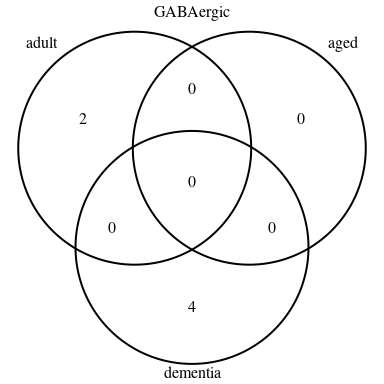

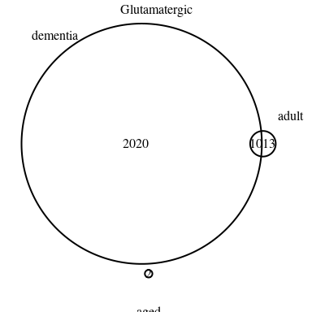

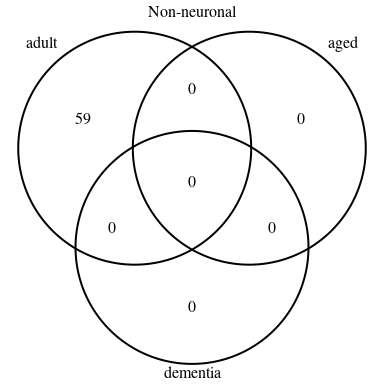

```r
## Randomized lists
set.seed(1)
rand_hvs <- varGenes_hvs2
rand_CT  <- varGenes_CT
rand_AD  <- varGenes_AD
for (ct in subclasses){
  rand_hvs$direction[rand_hvs$subclass==ct] <- sample(rand_hvs$direction[rand_hvs$subclass==ct],sum(rand_hvs$subclass==ct))
  rand_CT$direction[rand_CT$subclass==ct]   <- sample(rand_CT$direction[rand_CT$subclass==ct],sum(rand_CT$subclass==ct))
  rand_AD$direction[rand_AD$subclass==ct]   <- sample(rand_AD$direction[rand_AD$subclass==ct],sum(rand_AD$subclass==ct))
}

for (cl in sort(unique(classes))){
  adult_list <- rand_hvs$gene[is.element(rand_hvs$subclass,names(classes)[classes==cl])&(rand_hvs$direction=="high")]
  adult_list <- names(table(adult_list))[table(adult_list)>=(sum(classes==cl)/1.5)]
  aged_list  <- rand_CT$gene[is.element(rand_CT$subclass,names(classes)[classes==cl])&(rand_CT$direction=="high")]
  aged_list  <- names(table(aged_list))[table(aged_list)>=(sum(classes==cl)/1.5)]
  dem_list   <- rand_AD$gene[is.element(rand_AD$subclass,names(classes)[classes==cl])&(rand_AD$direction=="high")]
  dem_list   <- names(table(dem_list))[table(dem_list)>=(sum(classes==cl)/1.5)]
  geneListR  <- list(adult=adult_list, aged=aged_list, dementia=dem_list)
  print.ggExtraPlot(venn.diagram(geneListR,filename=NULL,main=cl))
}
```

Write out some lists for visual inspection and enrichment analysis using ToppGene.

```r
print_lists <- NULL
for (cl in sort(unique(classes))){
  adult    <- setdiff(varGene_classList[[cl]]$adult,c(varGene_classList[[cl]]$aged,varGene_classList[[cl]]$dementia))
  aged     <- setdiff(varGene_classList[[cl]]$aged,c(varGene_classList[[cl]]$adult,varGene_classList[[cl]]$dementia))
  dementia <- setdiff(varGene_classList[[cl]]$dementia,c(varGene_classList[[cl]]$aged,varGene_classList[[cl]]$adult))
  all      <- intersect(varGene_classList[[cl]]$dementia,intersect(varGene_classList[[cl]]$aged,varGene_classList[[cl]]$adult))
  print_lists <- rbind(print_lists,
                       cbind(adult,"adult only",cl),
                       cbind(aged,"aged only",cl),
                       cbind(dementia,"dementia only",cl),
                       cbind(all,"all groups",cl))
}
colnames(print_lists) <- c("Gene","Category","Class")
write.csv(print_lists,"variable_gene_lists.csv",row.names = FALSE)
```

Nothing particularly useful came out of the ToppGene analysis.

```r
ct = "Pvalb"
# Read in the cellxgene table for this subclass
fn     <- paste0("CZI/",convert[ct,])
dataIn <- readH5AD(fn)
countsTmp <- assay(dataIn,"X")
rownames(countsTmp) <- genesSEAAD
seu <- CreateSeuratObject(counts=countsTmp)  # seu is the seurat object with the data
met <- as.data.frame(colData(dataIn))
seu <- AddMetaData(seu,met)

# Subset to relevant CT and AD cells
keep_sub  <- keep_seaad&(seaad_metadata2$Subclass==ct)&is.element(seaad_metadata2$`Donor ID`,seaad_CT_donors)
samplesCT <- seaad_metadata2$sample_id[keep_sub]  # CONFIRM CORRECT IDS, then apply the cell sampling AFTER this step
keep_sub  <- keep_seaad&(seaad_metadata2$Subclass==ct)&is.element(seaad_metadata2$`Donor ID`,seaad_AD_donors)
samplesAD <- seaad_metadata2$sample_id[keep_sub]  # CONFIRM CORRECT IDS, then apply the cell sampling AFTER this step
seuCT <- seu[,samplesCT]
seuCT <- SetAssayData(seuCT,new.data=logCPM(seuCT@assays$RNA@counts),slot="data")
seuAD <- seu[,samplesAD]
seuAD <- SetAssayData(seuAD,new.data=logCPM(seuAD@assays$RNA@counts),slot="data")

# Prepare seurat objects
seuHVS <- seurat_all[[ct]][,is.element(seurat_all[[ct]]$donor_name,mtg_ep_donors)]
Idents(seuHVS) <- "donor_name"
Idents(seuCT)  <- "Donor.ID"  # May need to call this "donor-id" or something similar
Idents(seuAD)  <- "Donor.ID"  # May need to call this "donor-id" or something similar
```

Calculate coefficient of variation of gene donor means across the three data sets and find the most distinct genes in Pvalb subclass.

```r
mean_donor_HVS <- t(fmean(t(as.matrix(seuHVS@assays$RNA@data)),droplevels(seuHVS@meta.data$donor_name)))
meanHVS <- rowMeans(mean_donor_HVS)
sdHVS   <- rowSds(mean_donor_HVS); names(sdHVS) = names(meanHVS)
covHVS  <- sdHVS/(meanHVS+0.0001)
mean_donor_CT <- t(fmean(t(as.matrix(seuCT@assays$RNA@data)),droplevels(seuCT@meta.data$Donor.ID)))
meanCT  <- rowMeans(mean_donor_CT)
sdCT    <- rowSds(mean_donor_CT); names(sdCT) = names(meanCT)
covCT   <- sdCT/(meanCT+0.0001)
mean_donor_AD <- t(fmean(t(as.matrix(seuAD@assays$RNA@data)),droplevels(seuAD@meta.data$Donor.ID)))
meanAD  <- rowMeans(mean_donor_AD)
sdAD    <- rowSds(mean_donor_AD); names(sdAD) = names(meanAD)
covAD   <- sdAD/(meanAD+0.0001)
kpGn    <- intersect(names(meanHVS)[(meanHVS>=1)],names(meanCT)[(meanCT>=1)&(meanAD>=1)])
length(kpGn)
```

```
[1] 7562
```

Plot coefficient of variation of gene donor means across the three data sets and find the most distinct genes in Pvalb subclass.

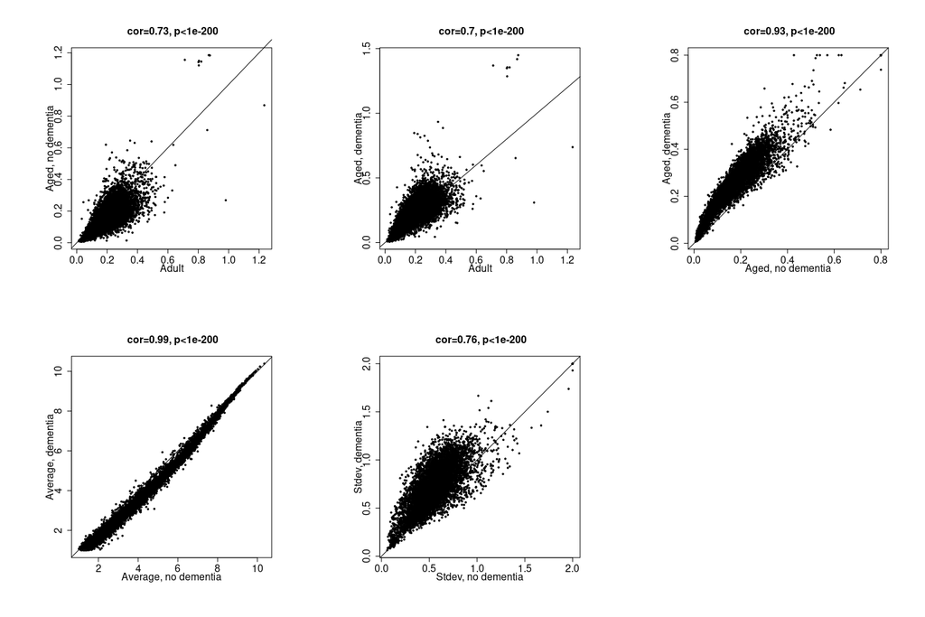

```r
plt <- as.ggplot(function(){
par(mfrow=c(2,3))
verboseScatterplot(covHVS[kpGn],covCT[kpGn],xlab="Adult",ylab="Aged, no dementia",cex=0.5,pch=10); abline(0,1)
verboseScatterplot(covHVS[kpGn],covAD[kpGn],xlab="Adult",ylab="Aged, dementia",cex=0.5,pch=10); abline(0,1)
verboseScatterplot(pmin(covCT[kpGn],0.8),pmin(covAD[kpGn],0.8),xlab="Aged, no dementia",ylab="Aged, dementia",cex=0.5,pch=10); abline(0,1)

verboseScatterplot(meanCT[kpGn],meanAD[kpGn],xlab="Average, no dementia",ylab="Average, dementia",cex=0.5,pch=10); abline(0,1)
verboseScatterplot(pmin(sdCT[kpGn],2),pmin(sdAD[kpGn],2),xlab="Stdev, no dementia",ylab="Stdev, dementia",cex=0.5,pch=10); abline(0,1)
})
plt
```

```r
ggsave("COV_scatterplot_comparisons_NSandSEAAD.pdf", plot=plt, height = 10, width = 15)
```

Plot some example genes that are either commonly variable or selectively variable in this study or SEA-AD in Pvalb interneurons.

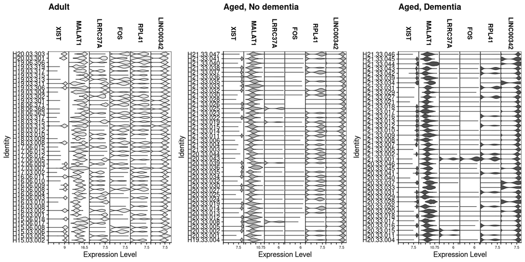

```r
gn <- c("MALAT1")  #c("CNTNAP2","DLGAP1",,"NRXN3","NRXN1",)
plotGene <- unique(c("XIST","MALAT1","LRRC37A","FOS","RPL41","LINC00342"))

# Trim outliers for better visualization of cross-donor variation
kpHVS = seuHVS[plotGene,apply(as.matrix(FetchData(seuHVS,gn)),1,min)>0]
kpCT  = seuCT[plotGene,apply(as.matrix(FetchData(seuCT,gn)),1,min)>0]
kpAD  = seuAD[plotGene,apply(as.matrix(FetchData(seuAD,gn)),1,min)>0]
for (gn in plotGene){
  a = as.matrix(kpHVS@assays$RNA@data)[gn,]
  kpHVS@assays$RNA@data[gn,(a>quantile(a,0.999))|(a<quantile(a,0.001))] = median(a)
  a = as.matrix(kpCT@assays$RNA@data)[gn,]
  kpCT@assays$RNA@data[gn,(a>quantile(a,0.999))|(a<quantile(a,0.001))] = median(a)
  a = as.matrix(kpAD@assays$RNA@data)[gn,]
  kpAD@assays$RNA@data[gn,(a>quantile(a,0.999))|(a<quantile(a,0.001))] = median(a)
}
p1 = VlnPlot(kpHVS,plotGene,stack=TRUE,cols = rep(studyColors[1],length(plotGene))) + NoLegend() + ggtitle("Adult")
p2 = VlnPlot(kpCT,plotGene,stack=TRUE,cols = rep(studyColors[2],length(plotGene))) + NoLegend() + ggtitle("Aged, No dementia")
p3 = VlnPlot(kpAD,plotGene,stack=TRUE,cols = rep(studyColors[3],length(plotGene))) + NoLegend() + ggtitle("Aged, Dementia")
grid.arrange(p1, p2, p3, ncol=3)
```

```r
ggsave("genes_violin_plots_HVS_SEAAD.pdf", plot=marrangeGrob(list(p1,p2,p3),nrow=1,ncol=3), height=7, width=14)
```

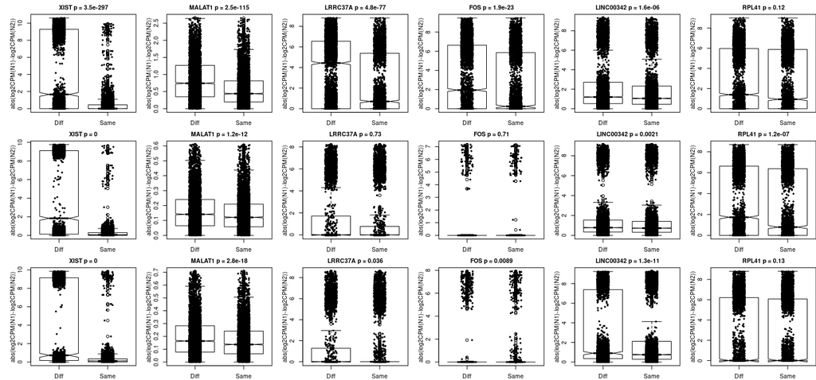

```r
plt <- as.ggplot(function(){
par(mfrow=c(3,length(plotGene)))
par(mar=c(2, 2, 2, 0))
for (gn in plotGene){
  varx <- c(gene_diffs_permuted[[ct]][gn,],gene_diffs[[ct]][gn,])
  varx[varx>=quantile(varx,0.995)] = NA  # clip outliers
  gp   <- c(rep("Diff",length(gene_diffs_permuted[[ct]][gn,])),rep("Same",length(gene_diffs[[ct]][gn,])))
  gp   <- gp[!is.na(varx)]
  varx   <- varx[!is.na(varx)]
  verboseBoxplot(varx,gp,main=gn,pt.cex=0.5, addScatterplot = TRUE, cex.lab=1, pch=19, cex.main = 1, cex.axis = 1,
                 xlab="",ylab="abs(log2CPM(N1)-log2CPM(N2))",col="white",pt.col = "black")
}
for (gn in plotGene){
  varx <- c(gene_diffs_permutedCT[[ct]][gn,],gene_diffsCT[[ct]][gn,])
  varx[varx>=quantile(varx,0.995)] = NA # clip outliers
  gp   <- c(rep("Diff",length(gene_diffs_permutedCT[[ct]][gn,])),rep("Same",length(gene_diffsCT[[ct]][gn,])))
  gp   <- gp[!is.na(varx)]
  varx   <- varx[!is.na(varx)]
  verboseBoxplot(varx,gp,main=gn,pt.cex=0.5, addScatterplot = TRUE, cex.lab=1, pch=19, cex.main = 1, cex.axis = 1,
                 xlab="",ylab="abs(log2CPM(N1)-log2CPM(N2))",col="white",pt.col = "black")
}
for (gn in plotGene){
  varx <- c(gene_diffs_permutedAD[[ct]][gn,],gene_diffsAD[[ct]][gn,])
  varx[varx>=quantile(varx,0.995)] = NA # clip outliers
  gp   <- c(rep("Diff",length(gene_diffs_permutedAD[[ct]][gn,])),rep("Same",length(gene_diffsAD[[ct]][gn,])))
  gp   <- gp[!is.na(varx)]
  varx   <- varx[!is.na(varx)]
  verboseBoxplot(varx,gp,main=gn,pt.cex=0.5, addScatterplot = TRUE, cex.lab=1, pch=19, cex.main = 1, cex.axis = 1,
                 xlab="",ylab="abs(log2CPM(N1)-log2CPM(N2))",col="white",pt.col = "black")
}
})
plt
```

```r
ggsave("exampleHighVarianceGenes_scatterplots_HVSvsSEAAD.pdf", plot=plt, height = 7, width = 15)
```

Some neuronal genes (including some Autism spectrum genes for some reason show higher variablilty in SEA-AD, whereas immediate early genes and MALAT1 are less variable.)